# Final Project

Michael Bevilacqua, Jonah Kotzen, Jaan Selod

2024-04-23

# Introduction:

The Myctophidae family includes the species *Diaphus mollis*, mesopelagic fish that reach body lengths of 6.6 cm (Froese and Pauly 2024). These myctophids are often called lantern fish, and can be found in Atlantic and Indian Oceans. They have a high evolutionary radiation, with high variability in phenotypes. This has resulted in the Myctophidae being one of the most abundant and “most species-rich deep-sea fish groups” Tuset (2018). In this study, we will be looking at the effect of Kármán vortices on several deceased Diaphus mollis, which vary in size. These vortices form after a constant flow of water hits an object in the water, which in a natural habitat could be a rock, or a tree, however in this circumstance, a wooden dowel is used. When the myctophid is placed in this street of vortices, fish “swimming behind cylinders adopt a distinctive, previously undescribed pattern of movement in order to hold station, which we term the Kármán gait” Liao (2003). This study will look to analyze whether or not dead Myctophids will display Kármán gaiting, similarly to dead trout, due to their body plans. Additionally, it is believed that differences in experimental parameters will result in varying oscillatory patterns amongst the different specimens.

[figure not shown]

# Methods:

# Results:

Table 1: Specimen Information

| Specimen | Body_Length_mm | Mass_g |
| --- | --- | --- |
| 1 | 53 | 1.477 |
| 2 | 45 | 0.910 |
| 3 | 48 | 0.855 |
| 4 | 28 | 0.160 |
| 5 | 38 | 0.468 |

```r
#code used to generate avi files from iphone videos

f <- list.files(full.names = T, pattern = ".MOV")
dir.create("images")
for (i in f) {
  if(dir.exists("images")) unlink("images", recursive = T)
  av_video_images(i, destdir = "images", format = "tiff")
  f.i <- list.files("images", full.names = T)
  av_encode_video(f.i, gsub("MOV", "avi", basename(i)), codec = "rawvideo")
}
```

# XY Processing

```r
# List all xy data files
file_list <- list.files(pattern = "_xy.csv")

# Read data and extract metadata from filenames
data_list <- lapply(file_list, function(file) {
  data <- read.csv(file)
  parts <- unlist(strsplit(file, "_"))
  species <- parts[1]
  flow <- gsub("xy.csv", "", parts[2])
  data <- mutate(data, Species = species, Flow = flow)
  return(data)
})

# Combine all data into one dataframe
combined_data <- bind_rows(data_list)
```

```r
# Remove unnecessary columns and clean names
processed_data1 <- combined_data %>%
  select(-matches("I..val.|Len..mm.|D2S..mm.|D2R..mm.|D2P..mm.|v..mm.sec.|x..unit.|y..unit.|Len..unit.|D2S..unit.|D2R..unit.")) %>%
  rename(
    x = x..mm.,
    y = y..mm.,
    time = t..sec.,
    alpha = α..deg.,
    delta_alpha = Δα..deg.
  )


# Rename the column for clarity
processed_data1 <- processed_data1 %>%
  rename(Specimen = Species)

# Convert Specimen to character type in the specimens dataframe
specimens$Specimen <- as.character(specimens$Specimen)

# Merging specimen data with the main dataset
processed_data1 <- processed_data1 %>%
  left_join(specimens, by = c("Specimen" = "Specimen"))
```

### Peak Data Calculations

```r
# Function to detect peaks (could use signal processing packages as well)
detect_peaks <- function(data_vector) {
  peaks <- which(diff(sign(diff(data_vector))) == -2) + 1
  return(peaks)
}

library(dplyr)

# Calculate the differences between consecutive Y values to find peaks and troughs
processed_data3 <- processed_data1 %>%
  arrange(Specimen, Flow, PID) %>%
  group_by(Specimen, Flow) %>%
  mutate(
    dy = c(NA, diff(y)),  # First difference is NA
    dy_prev = lag(dy),  # Shifted difference for peak/trough detection
    is_peak = dy_prev > 0 & dy <= 0,  # Peak when slope changes from positive to negative
    is_trough = dy_prev < 0 & dy >= 0  # Trough when slope changes from negative to positive
  )

# Calculate amplitude and frequency for each Specimen and Flow
analysis_results <- processed_data3 %>%
  group_by(Specimen, Flow) %>%
  summarise(
    amplitude = max(y[is_peak], na.rm = TRUE) - min(y[is_trough], na.rm = TRUE),
    num_cycles = sum(is_peak, na.rm = TRUE),  # Count peaks as cycle indicators
    total_time_seconds = (max(PID) - min(PID)) / 60,  # Convert frame count to seconds
    frequency = num_cycles / total_time_seconds,  # Cycles per second
    .groups = 'drop'
  )

processed_data4 <- processed_data1 %>%
  left_join(analysis_results, by = c("Specimen" = "Specimen"))
# View the results
print(analysis_results)
```

```
## # A tibble: 10 × 6
##    Specimen Flow  amplitude num_cycles total_time_seconds frequency
##    <chr>    <chr>     <dbl>      <int>              <dbl>     <dbl>
##  1 1        65         28.0          3              0.583      5.14
##  2 1        85         40.3          8              1.27       6.32
##  3 2        65         46.7         12              2.52       4.77
##  4 2        85         46.4         12              2          6
##  5 3        65         58.0          9              1.87       4.82
##  6 3        85         44.8         11              1.68       6.53
##  7 4        65         48.5         13              2.2        5.91
##  8 4        85         34.5          7              0.967      7.24
##  9 5        65         41.2         21              4.27       4.92
## 10 5        85         34.4         20              2.13       9.38
```

### Peaks and Troughs Inspection

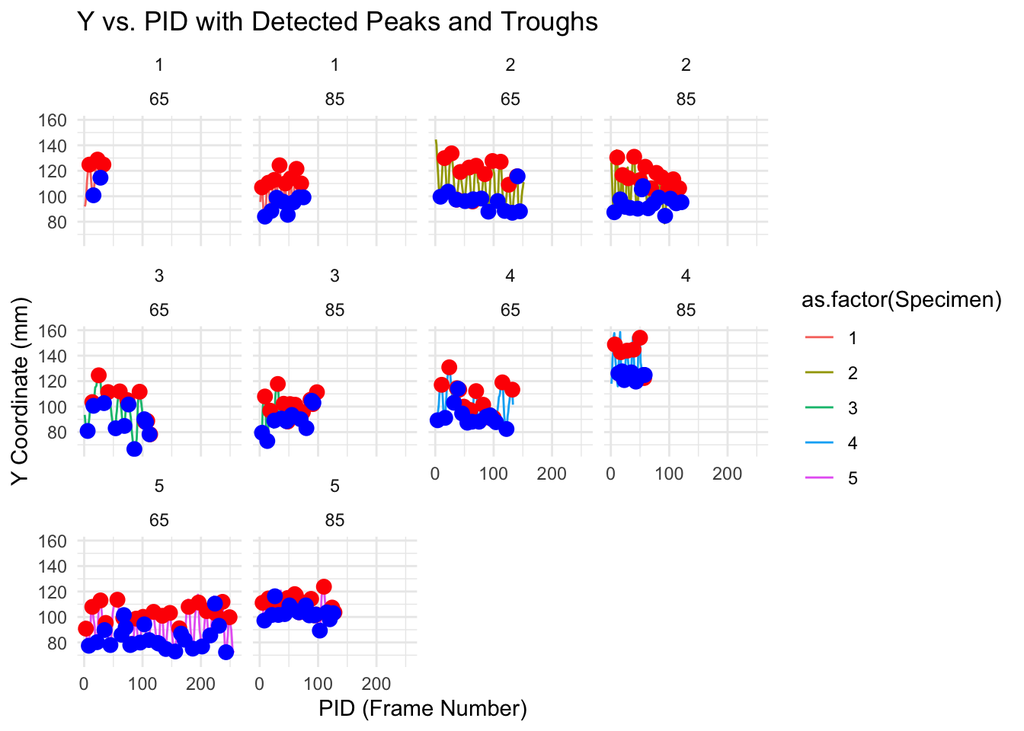

```r
ggplot(processed_data3, aes(x = PID, y = y, color = as.factor(Specimen))) +
  geom_line() +
  geom_point(data = subset(processed_data3, is_peak), aes(x = PID, y = y), color = "red", size = 3) +
  geom_point(data = subset(processed_data3, is_trough), aes(x = PID, y = y), color = "blue", size = 3) +
  facet_wrap(~Specimen + Flow) +
  labs(title = "Y vs. PID with Detected Peaks and Troughs",
       x = "PID (Frame Number)", y = "Y Coordinate (mm)") +
  theme_minimal()
```

# Graphs

### Plotting oscillatory patterns across flow speeds

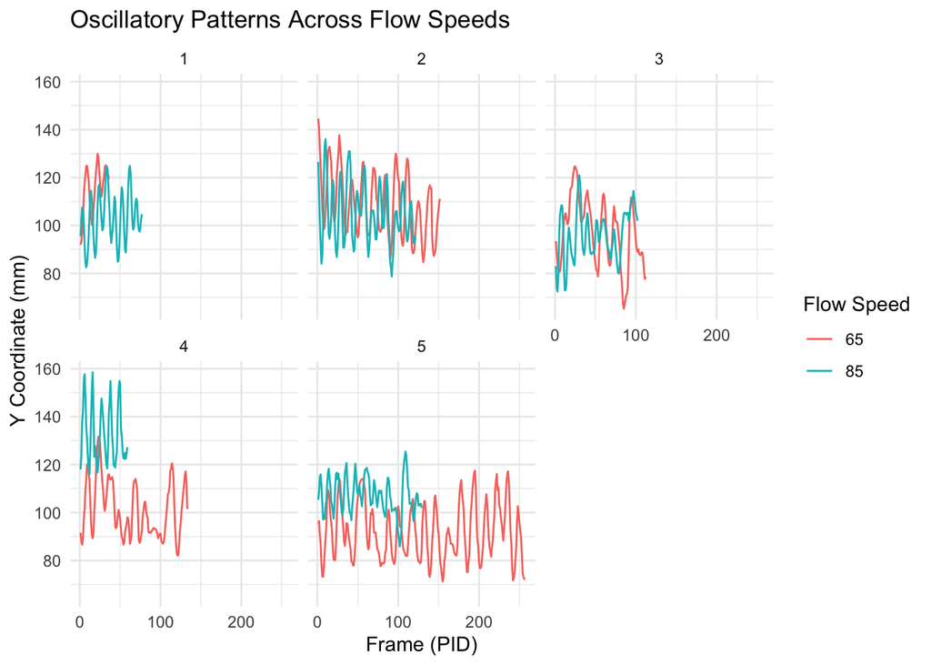

```r
ggplot(processed_data1, aes(x = PID, y = y, group = interaction(Specimen, Flow), color = as.factor(Flow))) +
  geom_line() +
  facet_wrap(~Specimen) +
  labs(title = "Oscillatory Patterns Across Flow Speeds",
       x = "Frame (PID)", y = "Y Coordinate (mm)",
       color = "Flow Speed") +
  theme_minimal()
```

### Mean Deviations in Y-Coordinates

```r
# Calculate mean deviations for each species and flow
deviation_data <- processed_data1 %>%
  group_by(Specimen, Flow) %>%
  summarise(mean_y = mean(y, na.rm = TRUE), sd_y = sd(y, na.rm = TRUE)) %>%
  ungroup()
```

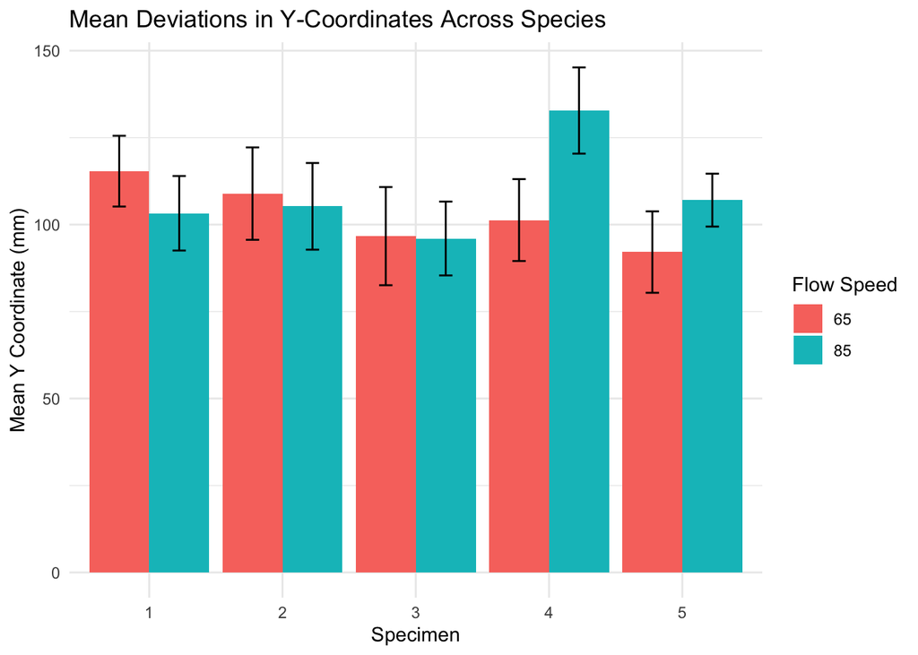

```r
# Plot mean deviations
ggplot(deviation_data, aes(x = Specimen, y = mean_y, fill = as.factor(Flow))) +
  geom_bar(stat = "identity", position = position_dodge()) +
  geom_errorbar(aes(ymin = mean_y - sd_y, ymax = mean_y + sd_y), width = .2, position = position_dodge(.9)) +
  labs(title = "Mean Deviations in Y-Coordinates Across Species",
       x = "Specimen", y = "Mean Y Coordinate (mm)",
       fill = "Flow Speed") +
  theme_minimal()
```

### Frequency, Amplitude, Time, Cycles

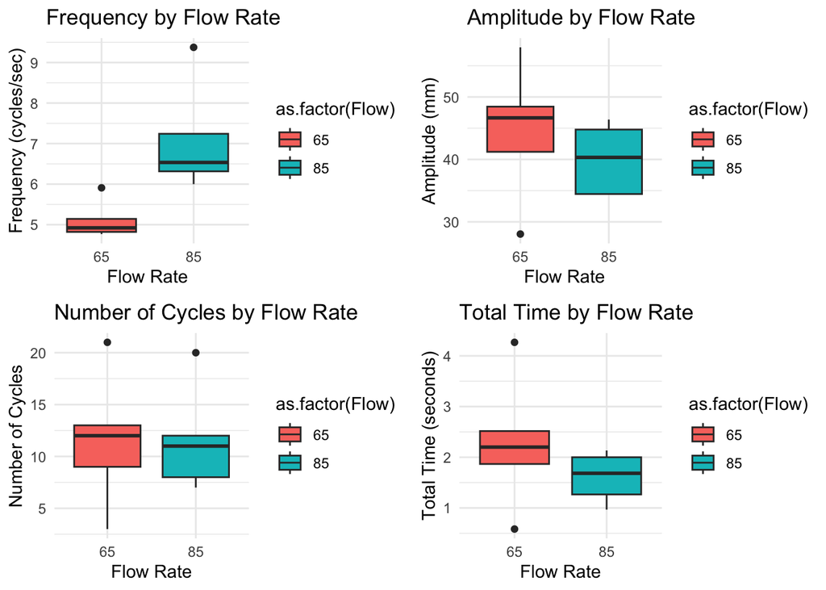

```r
grid.arrange(plot_frequency, plot_amplitude, plot_cycles, plot_total_time, ncol=2)
```

### Frequency Plots

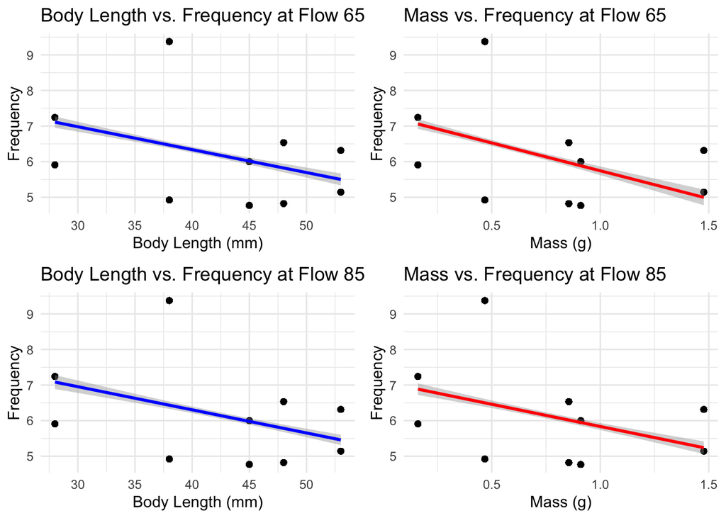

```r
# Arrange the plots in a grid
grid.arrange(plotW, plotX, plotY, plotZ, ncol = 2)
```

### Amplitude Plots

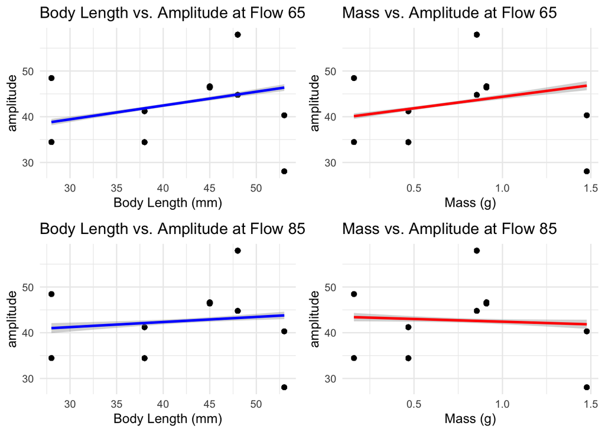

```r
# Arrange the plots in a grid
grid.arrange(plotA, plotB, plotC, plotD, ncol = 2)
```

### Combined plot for Body Length and Mass vs. Mean Y Deviation at Different Flow Speeds

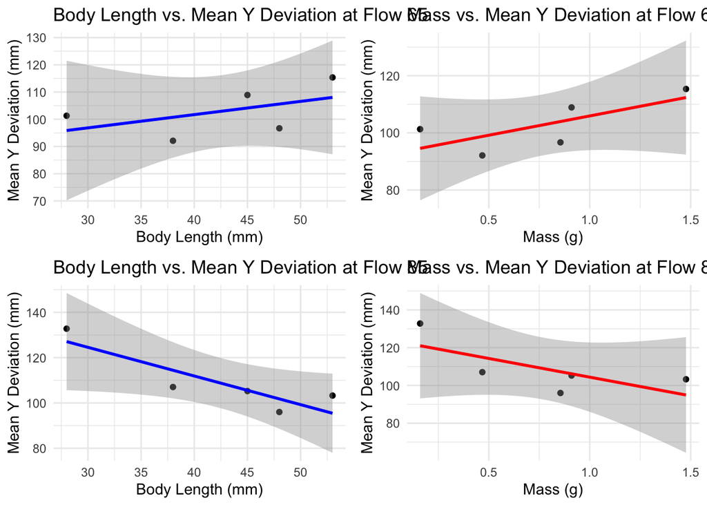

```r
# Arrange the plots in a grid
grid.arrange(plot1, plot2, plot3, plot4, ncol = 2)
```

### Effect of Flow Speed on PID Amount

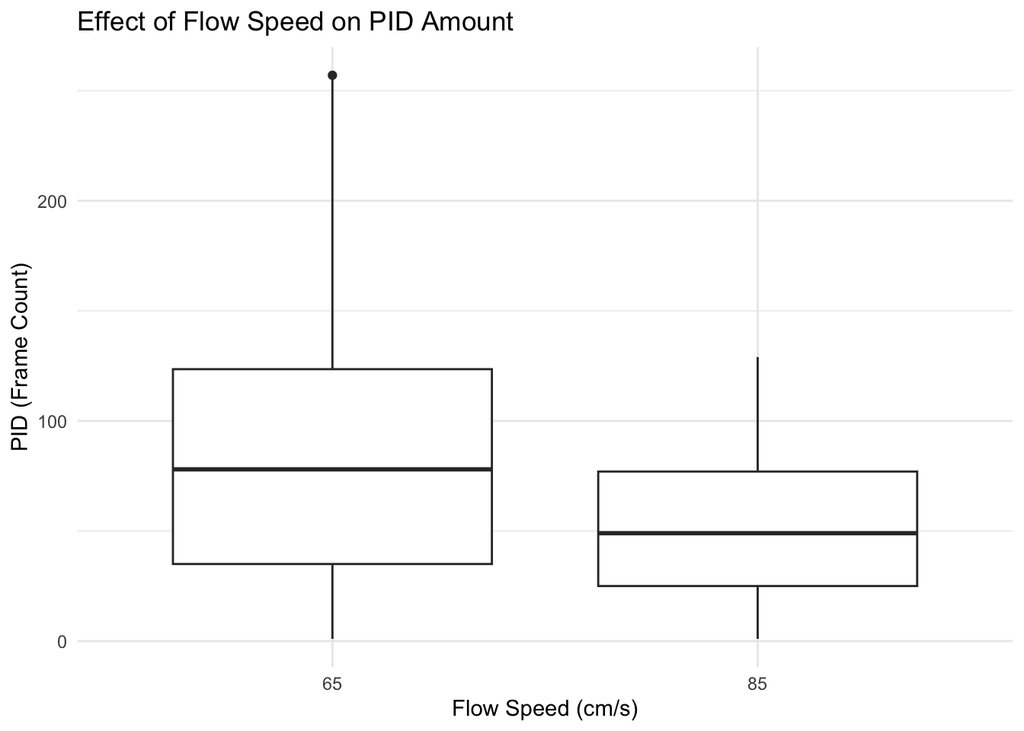

```r
ggplot(processed_data1, aes(x = Flow, y = PID, group = Flow)) +
  geom_boxplot() +
  labs(title = "Effect of Flow Speed on PID Amount",
       x = "Flow Speed (cm/s)", y = "PID (Frame Count)") +
  theme_minimal()
```

### Effect of Flow Speed on Mean Y Deviation

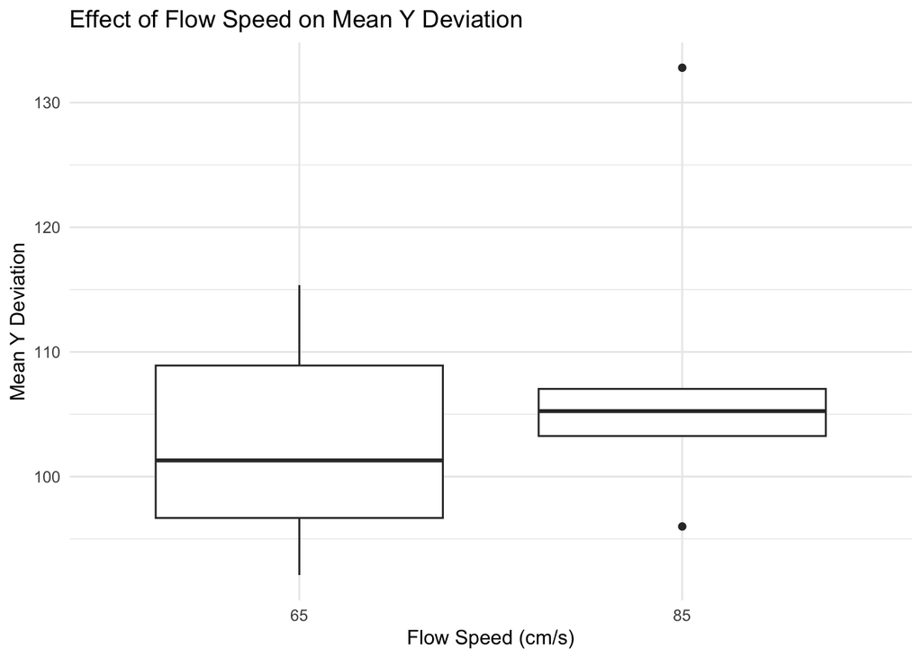

```r
ggplot(processed_data2, aes(x = Flow, y = mean_y_deviation, group = Flow)) +
  geom_boxplot() +
  labs(title = "Effect of Flow Speed on Mean Y Deviation",
       x = "Flow Speed (cm/s)", y = "Mean Y Deviation") +
  theme_minimal()
```

# Statistical Analysis

```r
# Running ANOVA for amplitude / flow
anova_amp <- aov(amplitude ~ Flow.x, data = processed_data4)
summary(anova_amp)
```

```
##               Df Sum Sq Mean Sq F value Pr(>F)
## Flow.x         1     26   26.36   0.476   0.49
## Residuals   2356 130359   55.33
```

```r
# Running ANOVA for frequency / flow
anova_freq <- aov(frequency ~ Flow.x, data = processed_data4)
summary(anova_freq)
```

```
##               Df Sum Sq Mean Sq F value   Pr(>F)
## Flow.x         1     29   29.01    11.7 0.000637 ***
## Residuals   2356   5844    2.48
## ---
## Signif. codes:  0 '***' 0.001 '**' 0.01 '*' 0.05 '.' 0.1 ' ' 1
```

```r
# Running ANOVA for amplitude / mass
anova_amp <- aov(amplitude ~ Mass_g, data = processed_data4)
summary(anova_amp)
```

```
##               Df Sum Sq Mean Sq F value   Pr(>F)
## Mass_g         1   1292  1292.4   23.59 1.27e-06 ***
## Residuals   2356 129093    54.8
## ---
## Signif. codes:  0 '***' 0.001 '**' 0.01 '*' 0.05 '.' 0.1 ' ' 1
```

```r
# Running ANOVA for frequency / mass
anova_freq <- aov(frequency ~ Mass_g, data = processed_data4)
summary(anova_freq)
```

```
##               Df Sum Sq Mean Sq F value Pr(>F)
## Mass_g         1    646   645.8   291.1 <2e-16 ***
## Residuals   2356   5227     2.2
## ---
## Signif. codes:  0 '***' 0.001 '**' 0.01 '*' 0.05 '.' 0.1 ' ' 1
```

```r
# Running ANOVA for amplitude / body length
anova_amp <- aov(amplitude ~ Body_Length_mm, data = processed_data4)
summary(anova_amp)
```

```
##                  Df Sum Sq Mean Sq F value Pr(>F)
## Body_Length_mm    1   6241    6241   118.4 <2e-16 ***
## Residuals      2356 124144      53
## ---
## Signif. codes:  0 '***' 0.001 '**' 0.01 '*' 0.05 '.' 0.1 ' ' 1
```

```r
# Running ANOVA for frequency / body length
anova_freq <- aov(frequency ~ Body_Length_mm, data = processed_data4)
summary(anova_freq)
```

```
##                  Df Sum Sq Mean Sq F value Pr(>F)
## Body_Length_mm    1    568   567.9   252.2 <2e-16 ***
## Residuals      2356   5305     2.3
## ---
## Signif. codes:  0 '***' 0.001 '**' 0.01 '*' 0.05 '.' 0.1 ' ' 1
```

# Discussion:

Our study explored the passive dynamic responses of deceased myctophids to varying flow conditions, emphasizing metrics such as amplitude, frequency, and number of cycles alongside mean lateral deviations. Remarkably, these fish exhibited behaviors akin to Kármán gaiting—a phenomenon typically associated with active swimming strategies in living fish. This underscores the mechanical nature of these interactions, suggesting that even in the absence of active muscular movements, fish bodies can align and respond to fluid dynamics in ways that mimic live swimming.

Moreover, pronounced variations in mean Y deviations and their standard deviations across flow conditions highlight that physical and mechanical properties, rather than active physiological adjustments, dictate these responses. For instance, Specimen 5 displayed an increase in frequency from 4.92 cycles/sec at Flow 65 to 9.38 cycles/sec at Flow 85, emphasizing how passive elements like body elasticity and shape can influence the kinematic response to different flow velocities.

These findings are crucial for understanding the ecological and evolutionary implications of fish body design. The passive Kármán gaiting observed suggests that fish morphology, evolved primarily for active swimming, also confers hydrodynamic advantages that can be harnessed passively. This insight has implications for energy conservation strategies in live fish and informs biomechanical models of fish locomotion, which often assume active control.

Furthermore, observing Kármán gaiting in dead fish provides a novel method to study the physical effects of water flows without the variability introduced by active swimming behaviors. This can help isolate the specific contributions of body shape and size to hydrodynamic efficiency, offering a clearer view of the mechanical underpinnings of fish swimming.

In conclusion, our study extends the understanding of fish biomechanics by demonstrating that deceased fish can still engage in behaviors like Kármán gaiting, purely through passive interactions with water flows. This underscores the importance of body design in aquatic locomotion and offers insights into how both living and deceased fish interact with their fluid environments, with direct implications for ecological modeling and the design of bio-inspired robotic systems in marine research.

This study is particularly significant as it extends findings traditionally obtained from trout—fish with a similar body plan to myctophids—by demonstrating that the passive biomechanical responses observed in trout can also be found in myctophids, thereby broadening the applicability of these observations across different species with similar hydrodynamic characteristics.

# Author Contributions:

- Michael: Intro, Methods, Writing
- Jonah: Graphs, Coding, Discussion
- Jaan: Video Analysis, Data Processing, Moral Support

# References:

Froese, R., and D. Pauly, eds. 2024. https://www.marinespecies.org/aphia.php?p=taxdetails&id=126595#attributes.

Liao, Beal, J. C. 2003. “The Kármán Gait: Novel Body Kinematics of Rainbow Trout Swimming in a Vortex Street.” *J Exp Biol* 206.

Tuset, Olivar, V. M. 2018. “Morpho-Functional Diversity in Diaphus Spp. (Pisces: Myctophidae) from the Central Atlantic Ocean: Ecological and Evolutionary Implications.” *ScienceDirect* 138: 46–59.